# 2 Niche Overlap Analysis using stable isotope data and nicheROVER

true  
June 24, 2024

This is a note from the course Community Ecology offered by [Universität Hamburg](https://www.biologie.uni-hamburg.de/en.html) and led by [Dr. Paula Cabral Eterovick](https://www.researchgate.net/profile/Paula-Eterovick-2), the source code of this article and the analysis can be found in my [course repository](https://github.com/zzzhehao/ComEco24).

# Niche Region and Niche Overlap Metrics

A new probabilistic method for quantifing n-dimensional ecological niche and niche overlap (Swanson et al. 2015).

We use the script written by Martin Lysy, Heidi Swanson which can be found [here](https://cran.r-project.org/web/packages/nicheROVER/vignettes/ecol-vignette.html), which requires the package “nicheROVER”.

“Fish” is a **fish stable isotope dataset** integrated in the package, containing values for three stable isotopes (N-15, C-13, S-34) measured in the muscle tissue of four arctic fish species (ARCS, BDWF, LKWF, LSCS). Use `?fish` for more details.

| species | D15N | D13C | D34S |
| --- | --- | --- | --- |
| ARCS | 12.18 | -23.89 | 13.07 |
| ARCS | 11.19 | -23.79 | 13.77 |
| ARCS | 12.05 | -22.88 | 14.03 |
| ARCS | 11.25 | -24.98 | 14.18 |
| ARCS | 12.08 | -25.82 | 11.84 |
| ARCS | 11.54 | -25.69 | 11.23 |
| ARCS | 12.64 | -22.72 | 12.46 |
| ARCS | 11.25 | -24.79 | 14.62 |
| ARCS | 10.94 | -26.99 | 11.26 |
| ARCS | 13.18 | -22.47 | 11.74 |

[output cut: 267 more lines]

## Why using SIA?

**Stable isotope analysis (SIA)** is a powerful tool in ecological niche analysis. Many physicochemical and biochemical processes are sensitive to differences in the dissociation energies of molecules, which often depend on the mass of the elements from which these molecules are made. Thus, the isotopic composition of many materials (expressed as $\delta$-values), including the tissues of organisms, often contains a label of the process that created it (Newsome et al. 2007). These “signatures” provides detailed insights into their ecological roles and interactions

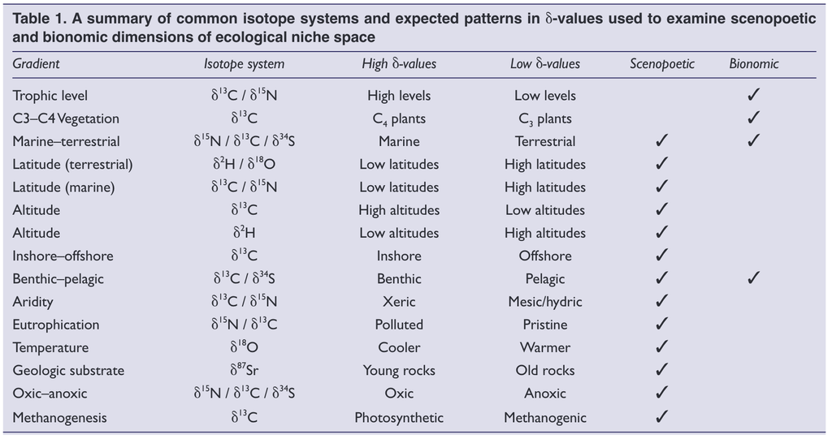

Common stable isotopes and different analysis options (Newsome et al. 2007).

**Reading list for more details in isotopic and atomic ecology**:

- Newsome et al. (2007)
- Michel (2021)
- Moyo et al. (2021)
- “Atomic Ecology - Analyzing Stable Isotope Data” (2024)

## Terminologies

Before we start analyzing our data, there are some concepts and prior knowledge need to be checked:

### Covariance, covariance matrix

**Covariance** is a measure of the joint variability of two variables, the sign of the covariance shows the tendency, i.e. one of the three possible linear relationshipss between two variables, which are:

- negative linear relationship, covariance is < 0
- no linear relationship, covariance is around 0
- positive linear relationship, covariance is > 0

The variance is a special case of the covariance in which the two variables are identical. The covariance itself is sensitive to the scale of the data, and it does not provide information of in what extent the two variables correlate with each other and how well the linear correlation fits the data. All these characteristics make covariance difficult to interpret, but it has become an important step stone for many interesting subsequent analysis, such as PCA, correlation analysis, etc..

A **covariance matrix** is a square matrix giving the covariance between each pair of elements, which is always symmetric and the diagonal elements present the variance of each variable.

For more information about covariance:

- [StatQuest](https://www.youtube.com/watch?v=qtaqvPAeEJY) on YouTube (simply and clearly explained)

### Bayesian statistics

van de Schoot et al. (2021) described the very foundation idea of the bayesian statistics as following:

Bayesian statistics is an approach to data analysis based on Bayes’ theorem, where available knowledge about parameters in a statistical model is updated with the information in observed data. The background knowledge is expressed as a **prior** distribution and combined with observational data in the form of a likelihood function to determine the **posterior distribution**.

The bayesian statistics based on the **Bayes’ theorem**, which is mathematically stated as following:

$$P(A|B)=\frac{P(B|A)P(A)}{P(B)}$$

where $A$ and $B$ are events and $P(B)\neq 0$,

- $P(A|B)$: the probability of event $A$ occurring given that $B$ is true. It is also called the posterior probability (briefly *posterior*) of $A$ given $B$.
- $P(B|A)$ is also a conditional probability: the probability of event $B$ occurring given that $A$ is true. It can also be interpreted as the likelihood of $A$ given a fixed $B$ because $P(B|A)=L(A|B)$. ($L$: likelihood)
- $P(A)$ and $P(B)$ are the probabilities of observing $A$ and $B$ respectively without any given conditions; they are known as the prior probability and marginal probability.

### Further useful concepts:

- Multivariate probability distribution
- Random vector

## Simulating random data

First of all, let’s take a view of isotope data of each species:

```r
aggregate(fish[2:4], fish[1], mean)
```

```
  species      D15N      D13C      D34S
1    ARCS 12.609420 -23.96812 14.565652
2    BDWF  9.270282 -26.70352 -3.149437
3    LKWF 11.036418 -25.15299  6.101493
4    LSCS 11.721000 -25.15471 11.451429
```

```r
aggregate(fish[2:4], fish[1], sd)
```

```
  species      D15N     D13C     D34S
1    ARCS 0.8227695 1.099111 1.243363
2    BDWF 1.1546972 2.014880 9.884178
3    LKWF 0.9122628 1.499837 4.765955
4    LSCS 0.7325401 1.216689 3.410886
```

The script uses `niw.post()` (random drawing from the posterior distribution with the Normal-Inverse-Wishart prior) to draw simulated data points.

### Normal-Inverse-Wishart (NIW) distribution

$$P(x |\text{species}=s) \backsim N(\mu_s \, , \Sigma_s)$$

**An explanation from [datamicroscope](https://datamicroscopes.github.io/niw.html#:~:text=Since%20the%20normal%20inverse%2DWishart,when%20we%20define%20our%20model.)**:

In practice, real valued data is commonly assumed to be distributed normally, or Gaussian. We could assume that conditioned on species, the measurement data followed a multivariate normal (above mentioned).

The normal inverse-Wishart distribution allows us to learn the underlying parameters of each normal distribution, its mean μs and its covariance $\Sigma_s$. Since the normal inverse-Wishart is the conjugate prior of the multivariate normal, the posterior distribution of a multivariate normal with a normal inverse-Wishart prior also follows a normal inverse-Wishart distribution. This allows us to infer the distirbution over values of $\mu_s$ and $\Sigma_s$ when we define our model.

**The explanation from [wikipedia](https://en.wikipedia.org/wiki/Inverse-Wishart_distribution#:~:text=In%20statistics%2C%20the%20inverse%20Wishart,of%20a%20multivariate%20normal%20distribution.)**:

In statistics, the inverse Wishart distribution, also called the inverted Wishart distribution, is a probability distribution defined on real-valued positive-definite matrices. **In Bayesian statistics it is used as the conjugate prior for the covariance matrix of a multivariate normal distribution**.

**Another explanation from [arxiv](https://arxiv.org/html/2405.16088v1#)**:

The normal-inverse-Wishart (NIW) distribution is commonly used as a prior distribution for the mean ($\mu$) and covariance ($\Sigma$) parameters of a multivariate normal distribution.

**My explanation of this formula**:

The probability of finding a specie given a **normal distribution** ($N$) of $\mu$ as niche parameter mean and $\Sigma$ as niche parameter covariance.

### Drawing with `niw.post()`

```r
# generate parameter draws from the "default" posteriors of each species
nsamples <- 1000
fish.par <- tapply(1:nrow(fish), fish$species,
            function(ii) niw.post(nsamples = nsamples, X = fish[ii,2:4]))
```

This resamples `nsamples`=1000 times from NIW distribution for each row in `fish` to generate the simulation data. As we categorized the observation by `fish$species`, we obtain a list of 4 with each of them containing a `nsample` long vector of $\mu$ and $\Sigma$ based on NIW distribution given the original data.

```r
# simulation data of the first specie
# num [1:3, 1:3, 1:1000] means a 3x3x1000 multi-dimentional array
str(fish.par[[1]])
```

```
List of 2
 $ mu   : num [1:1000, 1:3] 12.6 12.7 12.7 12.4 12.6 ...
  ..- attr(*, "dimnames")=List of 2
  .. ..$ : NULL
  .. ..$ : chr [1:3] "D15N" "D13C" "D34S"
 $ Sigma: num [1:3, 1:3, 1:1000] 0.651 0.126 0.702 0.126 0.851 ...
  ..- attr(*, "dimnames")=List of 3
  .. ..$ : chr [1:3] "D15N" "D13C" "D34S"
  .. ..$ : chr [1:3] "D15N" "D13C" "D34S"
  .. ..$ : NULL
```

This step and data structure is critical to later apply `niche.par.plot()`. For such reason, this step can be stored as a function for later utilization:

```r
niche.par <- function(data, index, n, pars) {
  par <- tapply(1:nrow(data), INDEX = index,
                function(r) niw.post(nsamples = n, X = data[r, pars]))
}
```

## Visualizing niche parameters

As mentioned above, the description (`?niche.par.plot()`) states the first argument has to be a *list with nspecies = length(niche.par), each element of which is a list with parameters mu and Sigma*. Use `plot.index`, `plot.mu` or `plot.Sigma` to select which $\mu$ or $\Sigma$ to plot, see details in the document.

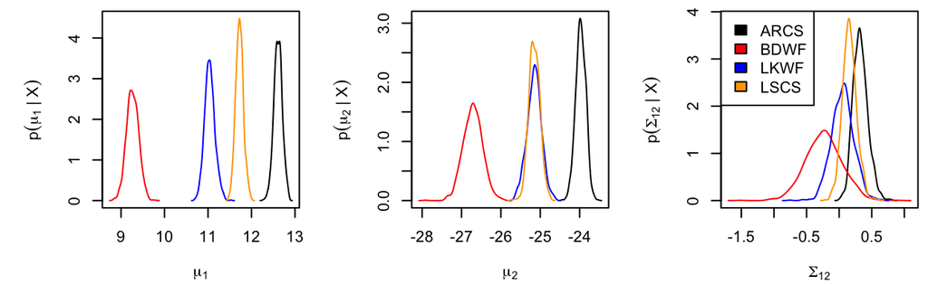

```r
clrs <- c("black", "red", "blue", "orange") # colors for each species

# mu1 (del15N), mu2 (del13C), and Sigma12
par(mar = c(4, 5, .5, .1)+.1, oma = c(0,0,0,0), pty="s", mfrow = c(1,3))
niche.par.plot(fish.par, col = clrs, plot.index = 1)
niche.par.plot(fish.par, col = clrs, plot.index = 2)
niche.par.plot(fish.par, col = clrs, plot.index = 1:2)
legend("topleft", legend = names(fish.par), fill = clrs)
```

## 2-d projection of a subset of a niche region

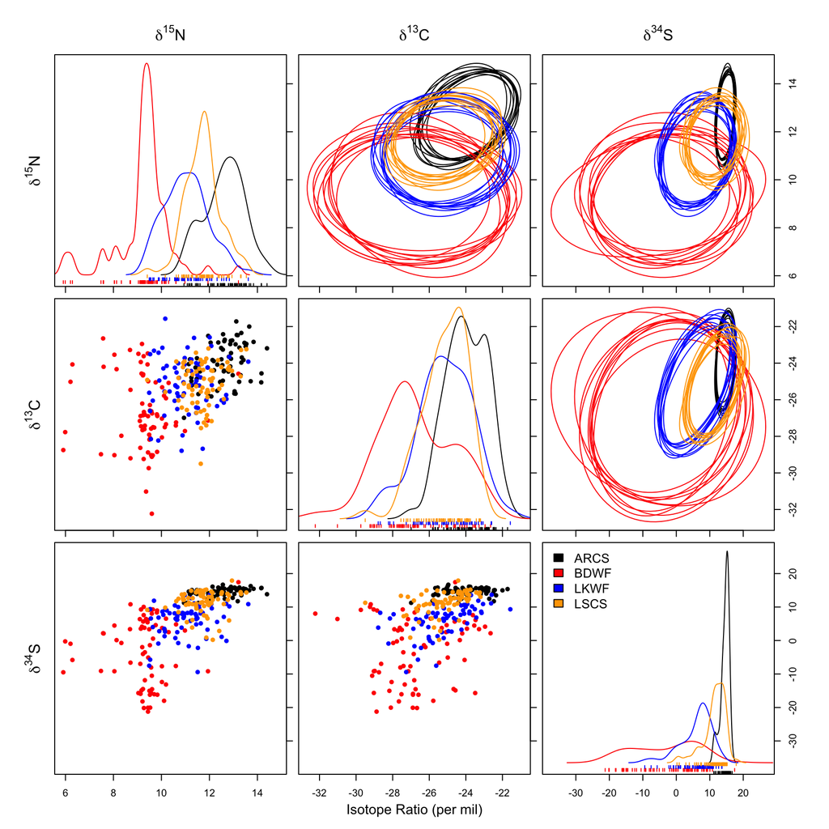

```r
nsamples <- 10
fish.par <- tapply(1:nrow(fish), fish$species,
                   function(ii) niw.post(nsamples = nsamples, X = fish[ii,2:4]))

# format data for plotting function
fish.data <- tapply(1:nrow(fish), fish$species, function(ii) X = fish[ii,2:4])

niche.plot(niche.par = fish.par, niche.data = fish.data, pfrac = .05,
           iso.names = expression(delta^{15}*N, delta^{13}*C, delta^{34}*S),
           col = clrs, xlab = expression("Isotope Ratio (per mil)"))
```

## Benthic or pelagic fish???????

According to Newsome et al. (2007) in table 1, also (find another source, maybe Duffill Telsnig et al. (2019)), we can use isotope system $\delta^{13}C$ and $\delta^{34}$S to estimate in which water column the species live. Comparing the estimated niche described by $\delta^{13}$C and $\delta^{34}$S of ARCS and BDWF, we see ARCS has more narrow region with higher $\delta$ values, meanwhile BDWF has a broader range with much part of it having lower $\delta$ values.

“Atomic Ecology - Analyzing Stable Isotope Data.” 2024. https://sites.google.com/view/brianhayden/teaching/analyzing-stable-isotope-data.

Duffill Telsnig, Jessica I., Simon Jennings, Aileen C. Mill, Nicola D. Walker, Andrew C. Parnell, and Nicholas V. C. Polunin. 2019. “Estimating Contributions of Pelagic and Benthic Pathways to Consumer Production in Coupled Marine Food Webs.” Edited by Andrew Jackson. *Journal of Animal Ecology* 88 (3): 405–15. https://doi.org/10.1111/1365-2656.12929.

Michel, Loïc. 2021. “Stable isotopes as descriptors of ecological niches,” December. https://doi.org/10.5281/zenodo.5765530.

Moyo, Sydney, Hayat Bennadji, Danielle Laguaite, Anna A. Pérez-Umphrey, Allison M. Snider, Andrea Bonisoli-Alquati, Jill A. Olin, et al. 2021. “Stable Isotope Analyses Identify Trophic Niche Partitioning Between Sympatric Terrestrial Vertebrates in Coastal Saltmarshes with Differing Oiling Histories.” *PeerJ* 9 (July): e11392. https://doi.org/10.7717/peerj.11392.

Newsome, Seth D., Carlos Martinez Del Rio, Stuart Bearhop, and Donald L. Phillips. 2007. “A Niche for Isotopic Ecology.” *Frontiers in Ecology and the Environment* 5 (8): 429–36. https://doi.org/10.1890/060150.1.

Swanson, Heidi K., Martin Lysy, Michael Power, Ashley D. Stasko, Jim D. Johnson, and James D. Reist. 2015. “A New Probabilistic Method for Quantifying *n* -Dimensional Ecological Niches and Niche Overlap.” *Ecology* 96 (2): 318–24. https://doi.org/10.1890/14-0235.1.

van de Schoot, Rens, Sarah Depaoli, Ruth King, Bianca Kramer, Kaspar Märtens, Mahlet G. Tadesse, Marina Vannucci, et al. 2021. “Bayesian Statistics and Modelling.” *Nature Reviews Methods Primers* 1 (1): 1–26. https://doi.org/10.1038/s43586-020-00001-2.